# Series temporales en R

# 9 MODELOS ARIMA

Los modelos de regresión exponencial y los ARIMA (o modelos de media movil integrada autoregresiva) son los más ampliamente utilizados para el pronóstico de series temporales. Los primeros se basan en la tendencia y estacionalidad de los datos y los ARIMA en la autocorrelación de las serie.

## 9.1 AR

Los modelos ARMA predicen los valores futuros mediante la combinación lineal de los valores pasados. Un modelos autoregresivo sigue la siguiente ecuación:
$$y_t=c+a_1y_t_−1+a_2y_t_−2+ ⋯+a_ y_t−p+e_t$$

## 9.2 MA

Los modelos MA predicen valores futuros mediante la combinación lineal de los errores de pronostico pasados.

## 9.3 ARIMA

Combinando diferenciación con modelos autoregesivos con media movil tenermos los ARIMA. La nomeclatura de los modelos ARIMA(p,d,q) significa:

- p= orden de la parte autorregresiva
- d = grado de diferenciación del modelo
- q = orden de la media movil

Muchos de los modelos que hemos descrito son casos especiales de ARIMA:

ruido blanco| ARIMA(0,0,0) |  
paseo aleatorio | ARIMA(0,1,0) |  
paseo aleatorio con deriva | ARIMA(0,1,0) |  
AR | ARIMA(p,0,0) |  
MA | ARIMA(0,0,q) |

Veamos un ejemplo de uso:

```r
    # Ajustamos un modelo ARIMA automáticamente  a la serie de oro
    fit <- auto.arima(gold)

    # Calculamos los residuos y el resumen
    checkresiduals(fit)
```

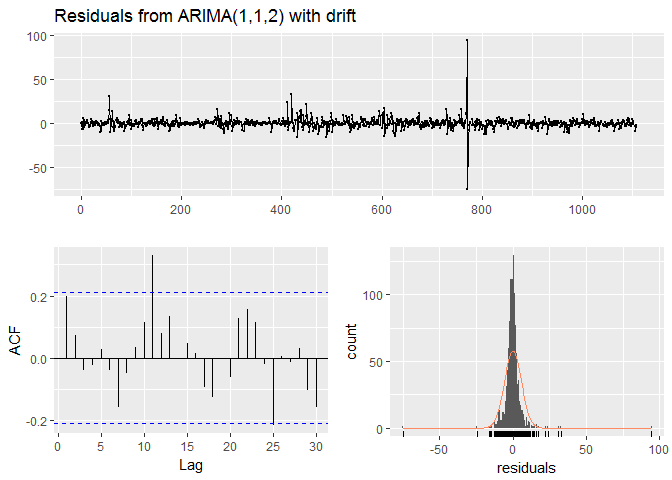

```
##
##  Ljung-Box test
##
## data:  Residuals from ARIMA(1,1,2) with drift
## Q* = 10.087, df = 6, p-value = 0.121
##
## Model df: 4.   Total lags used: 10
```

```r
    summary(fit)
```

```
## Series: gold
## ARIMA(1,1,2) with drift
##
## Coefficients:
##           ar1      ma1      ma2   drift
##       -0.1628  -0.1744  -0.0552  0.0713
## s.e.      NaN      NaN      NaN  0.1151
##
## sigma^2 estimated as 32.47:  log likelihood=-3410.82
## AIC=6831.64   AICc=6831.7   BIC=6856.69
##
## Training set error measures:
##                         ME     RMSE      MAE          MPE      MAPE
## Training set -0.0005567974 5.774345 3.097751 -0.008251843 0.7782533
##                  MASE        ACF1
## Training set 1.007258 0.003941559
```

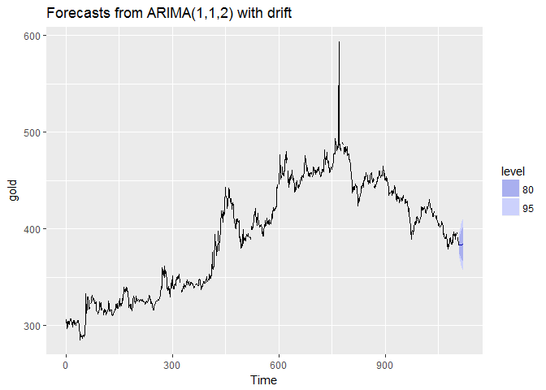

```r
    # Pintamos el pronostico para un año
    fit %>% forecast(h = 12) %>% autoplot()
```

```r
    # para un modelo concreto
    arima(lh, order = c(1,0,1))
    arima(USAccDeaths, order = c(0,1,1), seasonal = list(order = c(0,1,1)))

    autoplot(forecast(arima(lh, order = c(1,0,1))))

    fit <- auto.arima(presidents)
    fit %>% forecast(h = 12) %>% autoplot()
    predict(fit, 3)
```

## 9.4 Modelos ARIMA automáticos

La función `auto.arima()` da como resultado una formula del tipo siguiente: `ARIMA (p,d,q) (P,D,Q) [m]`, pr ejemplo ARIMA (0,1,4) (0,1,1) [12].

el significado de cada letra puede verse en la ayuda de la función, pero básicamente d es el orden de la primera diferenciación de la serie, D el de la frecuencia estacional

La función `auto.arima()` también funciona con datos estacionales, aunque hay que establecer `lambda = 0` (de BoxcCox) en la función para que la transformación de estaciionalidad de deshaga, es decir que el modelo se ajustará a los datos transformados, y que los pronósticos se transformarán de nuevo a la escala original.

Vamos a ver un ejemplo sobre los datos de precios del bitcoin.

[figure not shown]

```r
    # usamos los datos leidos de BTC
    pBTC1<-ts(na.omit(log(pBTC))) # quitamos NA y hacemos log
    # pintamos la grafica de log del BTC
    pBTC1 %>% autoplot()

    # Ajustamo un modelo ARIMA con lambda = 0
    fit <- auto.arima(pBTC1, lambda=0)

    # Resumen de resultados
    summary(fit)

    # Pintamos el pronostico para 60 días
    fit %>% forecast(h=60) %>% autoplot() #+ coord_cartesian(xlim = c(1800, 2050))
```

La función `auto.arima()` necesita estimar muchos modelos diferentes, y se usan varios atajos para tratar de hacer la función lo más rápido posible. Esto puede hacer que se devuelva un modelo que en realidad no tiene el valor de *AICc* más pequeño. Para hacer que `auto.arima()` trabaje más duro para encontrar un buen modelo, agregue el argumento opcional `stepwise = FALSE` para ver una colección de modelos mucho más grande.

```r
# Find an ARIMA model for euretail
fit2 <- auto.arima(pBTC1,stepwise = FALSE)
summary(fit2)

fit2 %>% forecast(h=60) %>% autoplot()
```

### 9.4.1 Comparando auto.arima() y ets()

Vamos a comparar los dos métodos semi automáticos de clclo de pronosticos, el modelo ets() y el auto.arima(). Lo haremos sobre los datos históricos de caudales maximos del río Nilo. Distinguiremos dos conjuntos de datos una de ensayo y otro de test.

```r
str(Nile) # vemos la serie de Nile
# Seleccionamos dos conjuntos de entrenamiento y prueba
train <- window(Nile, start =1871, end = 1960)
test<-window(Nile, start =1960, end = 1970)

# Ajustamos un modelos de arima y de ets a los datos de entrenamiento.
fit1 <- auto.arima(train)
fit2 <- ets(train)

# Vemos los residuos de cada caso. y como son parecidos
checkresiduals(fit1)
checkresiduals(fit2)

# HAcemos el pronostico a 10 años de cada modelo
fc1 <- forecast(fit1, h = 10)
fc2 <- forecast(fit2, h = 10)

# Use accuracy() to find better model based on RMSE
accuracy(fc1, Nile)
accuracy(fc2, Nile)

#Pintamos los resultados
autoplot(fc1,PI=F) + autolayer(fc2,PI=F,col="red") + autolayer(test)
```

[output not shown]

# 10 REGRESION DINÁMICA

La regreesión dinámica incorpora al conocimiento de los modelos relaciones de la serie temporal con otras series, ajustando los datos sgún la correlación que exista entre ellas. Se incorpora de esta manera información adicional

La función `auto.arima()` que ajusta un modelo de regresión puede incorporar información adicional de otras series que se aporta como parámetro adicional con el el argumento `xreg` que contiene una matriz de variables de regresión.

Vamos a ver un caso de ejemplo para tener las cosas más claras. La dataframe `datosESP` incluye datos de desempleo, precio de casas y exportaciones en España.

```r
    # Vemos la variable datosESP y la pintamos
    str(datosESP)
    plot.zoo(datosESP, col=c("red", "blue","brown"), lwd=2)

    # Ajustamos un modelo ARIMA
    fit <- auto.arima(datosESP[, "preciocasas"], xreg = datosESP[, "desempleo"], stationary = TRUE)

    fit <- auto.arima(datosESP$preciocasas, xreg = datosESP$desempleo, stationary = TRUE)

    # Chequeamos el modelo.
    # Este parametro concreto nos da el incremento de precio casa
    #por cada unidad de incremento de desempleo
    coefficients(fit)[3]
```

Ahora que tenemos el modelo, vamos a hacer el pronostico condicionado. Para ello primero calcularemos el pronostico de desempleo según la función lineal `ets()` para 2 años (8 trimestres), y con los datos de esta predicción haremos un pronostico del precio de la vivienda.

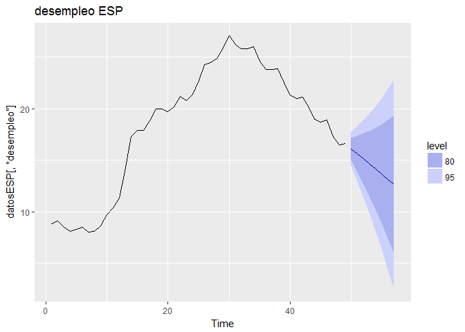

```r
    # 1. Ejecutamos un modelo ets() para el desempleo
    fit1<-ets(datosESP[, "desempleo"])
    pronostico_desempleo<-forecast(fit1,h=8)
    autoplot(pronostico_desempleo, main="desempleo ESP")
```

```r
    # 2. Predecimos el precio de la vivienda con el pronóstico anterior de desempleo en cuenta.
    fc <- forecast(fit1, xreg = pronostico_desempleo$mean)
    # Pintamos la predicción condicionada
    autoplot(fc, main="Pronostico reecio vivienda") +
        xlab("trimestres") + ylab("precio vivienda Index")
```

```r
# y si el desempleo se mantien constante en el 20% esos 2 años
    pronostico_desempleo<-rep(20,8)
    fc <- forecast(fit1, xreg = pronostico_desempleo)
    autoplot(fc, main="Pronostico reecio vivienda") +
        xlab("trimestres") + ylab("precio vivienda Index")
```

```r
# Y si el desempleo baja de forma escalonada hasta el 5% en 2 años
    fc <- forecast(fit1, xreg = c(18,15,10,8,5,5,5,5))
    autoplot(fc, main="Pronostico reecio vivienda") +
        xlab("trimestres") + ylab("precio vivienda Index")
```

## 10.1 Pronóstico de la demanda de electricidad

También puede modelar la demanda de electricidad diaria en función de la temperatura. Como puede haber visto en su factura de electricidad, se usa más electricidad en los días calurosos debido al aire acondicionado y en los días fríos debido a la calefacción.

Vamos a ver otro ejemplo de ajuste dinámico, en los datos de demanda electrica y temperatura. Como es sabido, cuando hace calor se enchufa el aire acondicionado, y cuando hace frio la calefacci´n, por lo que la demanda de energía guarda cierta relación física con la temperatura.

Tenemos un fichero que continen un año de datos diarios de demanda, temperatura y si es o no un dia normal o festivo almacenados en `elec.csv`

```r
    elec<-read.csv("elec.csv",sep = ";")
    # Time plots of demand and temperatures
    head(elec)
    str(elec)
    elec<-ts(elec, start = 1, frequency=7)
    autoplot(elec[, c("Demanda", "Temperatura")], facets = TRUE)

    # Matriz de regresión que usamos tem y wday
    xreg <- cbind(MaxTemp = elec[, "Temperatura"],
                  Workday = elec[, "Wday"])

    # Ajustamos el modelo de prediccion de la demanda
    fit <- auto.arima(elec[,"Demanda"], xreg = xreg)

    # Realizamos un pronostico para los 5 días siguientes
    # suponemos que la tem se queda en 30
    # y que son días normales 3 entre semana y 2 festivos seguidos
    prono5<-forecast(fit, xreg = cbind(rep(30,5),c(0,0,0,1,1)))
    autoplot(prono5, xlim = c(40, 55))
```